# La Política de la Corrupción

Sesión 11: Cleptocracia — A dónde va el dinero

Bogdan G. Popescu

bgpopescu@tec.mx

Tecnológico de Monterrey

## Acuérdense de Diego

La semana pasada este trato era toda la historia: tierra barata a cambio de una parte de las ganancias, y una ciudad que recibió menos de lo que debía.

- La parte fue para el hermano del funcionario. Desde ahí el dinero ya está a nombre de otra persona
- La ciudad perdió dinero que todavía no había cobrado: un descuento en la tierra. Hoy el dinero ya salió de un presupuesto
- Las torres de Diego sí se construyeron.
- Esta semana no se construye nada con el dinero que falta, y además el dinero no se queda en el país

Entonces, hoy:

- ¿cómo sale el dinero público?
- ¿cómo podría alguien contarlo?
- ¿dónde termina ese dinero?

## Hoy

**Se roban dinero público. ¿A dónde va?**

- Explicar por qué los ingresos que se saltan al contribuyente escapan a la fiscalización
- Seguir un pago robado desde un presupuesto público hasta un activo en el extranjero
- Decir por qué el beneficiario final es la pregunta decisiva en cada paso

Tres pasos:

- **ingreso no ganado**
- **captura**
- **ocultamiento**.

# I. El contrato fiscal

## Dos gobiernos, un presupuesto

Los dos recaudan 100 mil millones de dólares al año.

- El **Gobierno A** lo cobra a millones de contribuyentes
- El **Gobierno B** le vende petróleo a compradores extranjeros
- A tiene que convencer a millones de personas de seguir pagando
- B necesita mucho menos de sus propios ciudadanos

Mismo presupuesto. El Gobierno B tiene mucho menos motivo para negociar.

## ¿Quién está en el circuito?

[figure not shown]

En A el ciudadano está dentro del circuito, y ese circuito es lo que mantiene el dinero fluyendo. En B nada apunta hacia él.

## El contrato fiscal

Cobrar impuestos sale más barato cuando la gente cree que el cobro es justo, así que vale la pena comprar su consentimiento. La fiscalización es el precio.

Los politólogos llaman a ese pacto el **contrato fiscal**.

Es una tendencia, no una ley. Muchos Estados han cobrado impuestos de manera fuerte y coercitiva.

El Gobierno B nunca tiene que hacer ese pacto. Hay dos palabras para lo que tiene en su lugar.

## Ingreso caído del cielo y renta

**Ingreso caído del cielo**

Dinero que un gobierno nunca tuvo que pedirle a sus propios ciudadanos.

Hace un momento los dos gobiernos recaudaron 100 mil millones. A tuvo que convencer a millones de contribuyentes. B nada más le vendió petróleo a extranjeros.

**Renta**

La diferencia entre lo que cuesta producir algo y el precio al que se vende.

Un barril de petróleo cuesta **$20** extraerlo y se vende en **$80**. Los $20 pagan el trabajo. Los **$60** están ahí porque el petróleo ya estaba en el subsuelo.

Al ingreso de un casero también se le llama renta por la misma razón: viene de ser dueño de algo, no de hacer algo.

Todos los casos de esta sesión son alguien quedándose con una parte de una renta que llegó como dinero caído del cielo.

## ¿El patrón aparece en los datos?

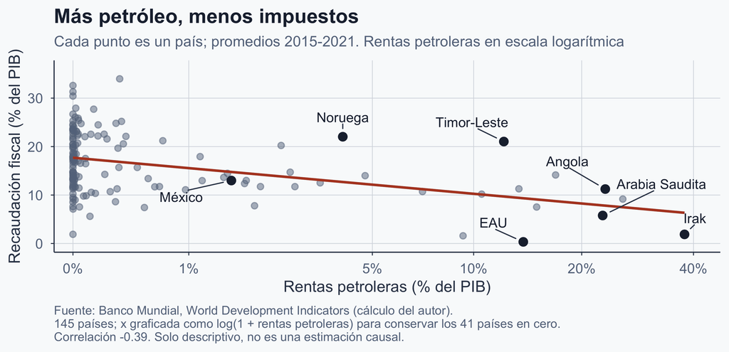

Es una correlación, y una correlación no demuestra causalidad. La dirección sí es la que predice la teoría.

## Del petróleo a la ayuda

El problema no es el petróleo. Es **de dónde viene el ingreso del gobierno**.

- Cuando los gobiernos dependen de los contribuyentes, los ciudadanos tienen poder de negociación
- Cuando el dinero llega de fuera, ese poder se puede debilitar
- La **ayuda externa** genera un problema parecido

Pero se supone que la ayuda sirve para construir caminos, clínicas y escuelas.

**Si un donante le da más dinero a un gobierno, ¿de verdad llega más a la gente a la que se quiere ayudar?**

# II. Atrapar el dinero cuando sale

## La ayuda también cae del cielo

- La ayuda llega del extranjero; el gobierno no tuvo que sacarla de sus propios contribuyentes
- Igual que el ingreso petrolero, llega al Estado sin haberse negociado antes con los ciudadanos
- En los 50 países más dependientes de la ayuda en los datos de Svensson, la ayuda financió el **53.8% del gasto del gobierno central**

Así que la ayuda plantea el mismo problema de fondo que el petróleo. Pero el argumento de Svensson es más filoso: **más dinero de fuera puede significar menos clínicas, no más.**

## Un donante duplica el presupuesto

> Un ministerio de salud tiene **100** para clínicas. Un donante le agrega **100** más. Dos gobernadores quieren que las clínicas nuevas se construyan cada uno en su estado.

**Ninguno de los dos puede simplemente quedarse con el dinero. Así que cada uno gasta para ganárselo:**

- Vuela a la capital, contrata consultores, encarga un estudio de factibilidad, pone personal de tiempo completo a trabajar al ministro
- Cada peso y cada hora de funcionario que se va en eso no construye ninguna clínica

**Entonces, ¿cuánto de los 200 llega a una clínica?**

## ¿Más dinero, menos clínicas?

**Un experimento mental.** Supongamos que los dos gobernadores pelean por la bolsa más grande:

- El presupuesto es un **bien común**: entre más crece, más vale la pena pelear por él
- Svensson (2000): esto *puede* pesar más que el dinero extra, a menos que el donante pueda amenazar de forma **creíble** con retirarlo

## ¿Qué es el Banco Mundial?

No es un banco donde usted pueda abrir una cuenta.

- Sus gobiernos miembros son los dueños, México entre ellos
- Presta y dona dinero a los **gobiernos** de los países más pobres
- Para proyectos: caminos, clínicas, escuelas, energía
- Tiene dos brazos: la **AIF**, Asociación Internacional de Fomento, para los países más pobres
- Y el **BIRF**, Banco Internacional de Reconstrucción y Fomento, para los de ingreso medio

El dinero aterriza en una secretaría de hacienda. De ahí en adelante, los funcionarios deciden a quién se le paga.

## Entonces, ¿cómo sale el dinero?

Hace rato los gobernadores no podían simplemente quedarse con el dinero. Supongamos ahora que un funcionario sí puede.

> Un ministerio tiene **$10 millones** del Banco Mundial para un camino rural.
- Un funcionario le da el contrato a una empresa, con un acuerdo por debajo
- La empresa factura los **$10 millones** completos y construye **$6 millones** de camino
- Se queda con parte de la diferencia de **$4 millones** y le manda al funcionario **$2.5 millones**

Ese pago de regreso es un **moche**: un pago secreto que alguien recibe a cambio de darle a otra persona o empresa un contrato o un favor.

Cada documento está completo, autorizado y, a primera vista, es legal. **El robo son los papeles**.

## ¿Nadie se daría cuenta?

No falta nada. El ministerio pagó **$10 millones** y el camino existe.

- Una conciliación de rutina no encuentra nada. La pérdida está en el **precio**, no en la contabilidad
- Para verla hay que saber que el camino debía haber costado **$6 millones**
- Eso requiere el presupuesto de un ingeniero, una inspección, y alguien con capacidad de actuar
- Y el moche salió de la cuenta de la **empresa**, que el ministerio no puede auditar

Así que sí se descubre con frecuencia, pero tarde, y casi siempre gracias a periodistas o a un fiscal extranjero.

## Todos los bancos saben quién eres

Abra una cuenta donde sea y el banco tiene que registrar quién es usted. Casi todos los países lo exigen.

- El banco guarda su saldo y reporta sus totales a su propio banco central
- Esos registros son la razón por la que el dinero se puede rastrear
- Por eso un ladrón no puede simplemente meter fondos públicos robados a un banco de su país

Mover el dinero es fácil. Lo difícil es mantener tu nombre fuera del registro que **cualquier otro** puede consultar.

## Cómo se ve en realidad un “paraíso fiscal”

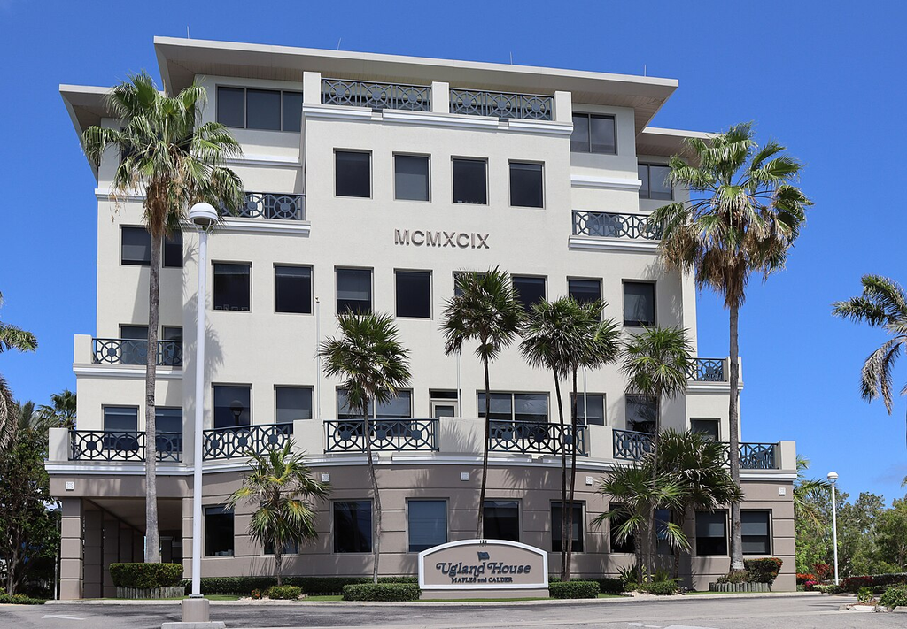

Ugland House, George Town, Islas Caimán: el domicilio registrado de miles de empresas.

- El edificio es real; casi ninguna de esas empresas opera ahí
- Un paraíso fiscal vende **secreto y protección de activos**, legalmente
- La cuenta está a nombre de una *empresa*. El banco está obligado a saber quién está detrás; **alguien de fuera no lo puede averiguar**

Foto: Coolcaesar, Wikimedia Commons, CC BY 4.0.

## ¿Por qué no dejarlo en su país?

El funcionario ahora tiene **$2.5 millones** que no puede explicar. Dónde los ponga decide si se los queda.

**Un banco en su país**

- La cuenta está **a su nombre**
- Un auditor, un periodista o el siguiente gobierno la pueden encontrar
- Un juez la puede congelar y ordenar que se devuelva

**Un paraíso fiscal, a través de una empresa**

- La cuenta está a nombre de la **empresa**
- Sus propios jueces no pueden sin más ordenar que regrese
- Un investigador primero tiene que probar que la empresa es suya

El robo ocurrió en su país. El paraíso fiscal es lo que lo vuelve **difícil de deshacer**.

## ¿Un funcionario o un patrón?

Fue un solo contrato, y no tuvo nada de extraordinario.

- La misma oportunidad aparece con cada pago grande que asigna un funcionario
- Cuando suficientes se quedan con una parte, deja de ser una anécdota
- **Captura por las élites:** quienes controlan el dinero público se quedan con una parte

Pero acabamos de decir que en su propio país no se ve: los pagos cuadran y las cuentas de la empresa son privadas.

Entonces, ¿cómo podría alguien **medirlo** en todo un país?

## Síganlo fuera del país

El paraíso fiscal está hecho para esconder el dinero. Pero un banco en el extranjero de todos modos tiene que **anotar el depósito**, y reportar sus totales.

Ahí está la rendija. Un auditor nacional no puede ver dentro de esas cuentas. El registro bancario internacional sí las puede contar.

**Usted sabe las fechas en que el Banco Mundial desembolsó. Sabe lo que reportan cada trimestre los bancos extranjeros. ¿Dónde buscaría?**

```
%%{init: {"flowchart": {"useMaxWidth": true, "htmlLabels": false, "nodeSpacing": 45, "rankSpacing": 90, "padding": 45, "curve": "basis"}, "themeVariables": {"fontSize": "22px", "fontFamily": "Helvetica Neue, Helvetica, Arial, sans-serif"}, "width": 1150, "height": 620}}%%
flowchart LR
  A["El Banco Mundial<br/>envía la ayuda"] --> B["¿Qué bancos del exterior<br/>reciben depósitos?"]
  B --> C["Paraísos fiscales<br/>(Suiza)"]
  B --> D["Bancos comunes<br/>(Alemania, Suecia)"]
  C --> E["Los depósitos saltan<br/>ese mismo trimestre"]
  D --> F["Los depósitos<br/>no se mueven"]
  classDef q fill:#1e293b,stroke:#1e293b,stroke-width:2px,color:#ffffff
  classDef hit fill:#b44527,stroke:#1e293b,stroke-width:2px,color:#ffffff
  classDef null fill:#e5e7eb,stroke:#334155,stroke-width:2px,color:#1e293b
  class A,B q
  class C,E hit
  class D,F null
```

Ilustración del autor sobre el diseño de investigación de Andersen et al. (2022).

## ¿Cuál patrón lo convencería?

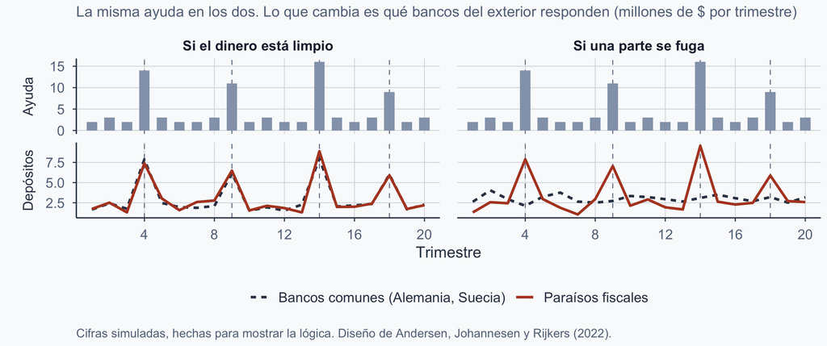

En los dos mundos el dinero sale del país. En el segundo, **solo** a donde se puede esconder al dueño.

## ¿De dónde salen estos números?

**Andersen, Johannesen y Rijkers** hicieron exactamente esto, en el *Journal of Political Economy* (2022). Es su lectura obligatoria. Pusieron dos registros públicos uno al lado del otro.

**La ayuda:** cada préstamo y cada donativo del Banco Mundial es un registro público, proyecto por proyecto, mes por mes. Ellos los suman por país y por trimestre.

**Los depósitos:** el **Banco de Pagos Internacionales (BPI)** es el banco de los bancos centrales, en Basilea. Los bancos de **43 centros financieros** le reportan cada trimestre cuánto les deben a los residentes de cada país. 17 de esos centros son paraísos fiscales.

Así que un renglón de estos datos dice: *este trimestre, los residentes de Tanzania tenían esta cantidad en bancos suizos.* Un número, por par de países, por trimestre.

Los datos no traen **ni nombres ni números de cuenta**. Usted no puede buscar al presidente de ningún país. Los autores lo dicen con todas sus letras: “no observamos quién guarda riqueza en los paraísos fiscales”.

## El resultado principal

En los países que más dependen de la ayuda, cada **$100** del Banco Mundial que llegan vienen acompañados de unos **$7.50** más en cuentas de paraísos fiscales ese mismo trimestre.

- En los **7 países más dependientes** de la ayuda: más de **$15**
- Los depósitos en bancos **comunes**, Alemania y Suecia, no se mueven nada

**Antes de aceptarlo: ¿qué más podría producir esto?** Las empresas y los bancos centrales sí guardan dinero en el extranjero.

Pero eso también movería a Alemania. Solo reaccionan los paraísos fiscales, y esa asimetría es el argumento.

Nadie rastreó los **$2.5 millones** del funcionario. Esto es la **forma** que dejan esos pagos, contada en todo un país.

Muestra: los 22 países donde la ayuda supera el 2% del PIB, 1990-2010. Los datos muestran depósitos, no depositantes.

## Entre más depende un país de la ayuda

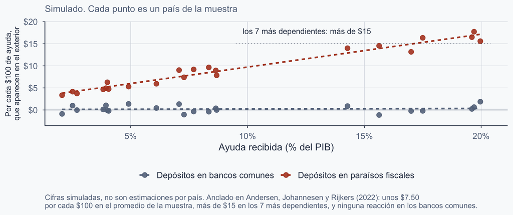

Los puntos son inventados. La **pendiente** es el hallazgo.

## Ejercicio 1 — ¿Qué deberían hacer los donantes?

> En los países que más dependen de la ayuda, alrededor del 7.5% de un desembolso aparece en el exterior ese mismo trimestre.

**Elija una postura y dé su mejor razón:**

1. **Recortar la ayuda** a los países donde más se fuga
2. **Mantener la ayuda, poner condiciones**, y decir quién las verifica
3. **Cambiar el canal**: saltarse por completo a la hacienda pública

# III. A dónde va el dinero

## ▶ La industria de las empresas fantasma

[video not shown]

1. Mossack Fonseca quería ser “el McDonald’s del sistema offshore”. ¿Qué les dice eso sobre cuántas de estas empresas existen?  
2. “No te importa quién está realmente detrás.” ¿De quién era el trabajo de que sí le importara?  
3. Nada de lo que sale en este clip es un robo. Entonces, ¿qué era exactamente lo que se vendía?

Business Insider, “How The Wealthy Hide Billions Using Tax Havens”, con Jake Bernstein (ICIJ). Clip 2:21-3:35 de 5:11. Subtítulos: ES / EN en el reproductor.

## Las respuestas

1. Mossack Fonseca quería ser “el McDonald’s del sistema offshore”. ¿Qué les dice eso sobre cuántas de estas empresas existen?

- Mucho volumen, bajo costo, un producto estándar que se vende de línea. La cifra del propio clip: unas **214,000** entidades en los Papeles de Panamá, y casi la mitad registradas en las Islas Vírgenes Británicas

2. “No te importa quién está realmente detrás.” ¿De quién era el trabajo de que sí le importara?

- Del despacho que constituyó la empresa, y del banco que le abrió la cuenta. Los dos están obligados a identificar al dueño
- Al **registro público** de empresas normalmente no se le exigía preguntar nada. Ese hueco es el que cierra un registro de beneficiarios finales

3. Nada de lo que sale en este clip es un robo. Entonces, ¿qué era exactamente lo que se vendía?

- **Anonimato.** Venderlo es legal. Lo que algunos compradores hacen después con él, no

## El dinero en un banco sigue siendo prueba

Un pago robado que está en una cuenta bancaria sigue siendo prueba.

- Se puede congelar, rastrear y devolver
- Para gastarlo con seguridad, tiene que parecer ganado
- Propiedades, acciones, una empresa: activos con una explicación inocente

Así que el dinero necesita un nuevo dueño en el papel antes de poder gastarse.

Esconder la propiedad es todo el trabajo.

## Qué es una empresa fantasma

Una empresa que existe legalmente y no hace nada.

- Registrada, con capacidad de tener una cuenta y de ser dueña de bienes
- Sin empleados, sin oficinas, sin actividad
- Su dueño registrado puede ser **otra empresa**, en otro país

Apile tres de esas en tres jurisdicciones distintas y la pregunta “¿de quién es este dinero?” ya no tiene respuesta alcanzable desde fuera.

Quien realmente lo controla es el **beneficiario final**. Los investigadores necesitan ese nombre, y la estructura existe justamente para no darlo.

## Un pago, seis pasos

```
%%{init: {"flowchart": {"useMaxWidth": true, "htmlLabels": false, "nodeSpacing": 40, "rankSpacing": 70, "padding": 40, "curve": "basis"}, "themeVariables": {"fontSize": "21px", "fontFamily": "Helvetica Neue, Helvetica, Arial, sans-serif"}, "width": 1150, "height": 620}}%%
flowchart LR
  A["Presupuesto público<br/>o pago de ayuda"] --> B["Contrato a un<br/>proveedor favorecido"]
  B --> C["Factura por obra<br/>que no se hizo"]
  C --> D["Empresa fantasma,<br/>y luego otra"]
  D --> E["Cuenta en una<br/>jurisdicción opaca"]
  E --> F["Departamento, acciones,<br/>yate en el extranjero"]
  classDef pub fill:#4a7c6f,stroke:#1e293b,stroke-width:2px,color:#ffffff
  classDef cap fill:#b44527,stroke:#1e293b,stroke-width:2px,color:#ffffff
  classDef hid fill:#334155,stroke:#1e293b,stroke-width:2px,color:#ffffff
  classDef ast fill:#b7943a,stroke:#1e293b,stroke-width:2px,color:#ffffff
  class A pub
  class B,C cap
  class D,E hid
  class F ast
```

Solo los pasos 4 y 5 tienen que ver con el secreto. El dinero se pierde en el paso 3, en el precio.

Ilustración del autor. Compare la tipología de casos en van der Does de Willebois et al. (2011).

## Nadie hace esto solo

Cada paso necesita a alguien con licencia para darlo.

- Un **despacho constituidor** registra las empresas fantasma
- Un **abogado** aparece como prestanombres, o mueve el dinero por la cuenta de clientes del despacho
- Un **contador** firma la factura
- Un **banquero** acepta al cliente y no reporta nada
- Un **agente inmobiliario** cierra la compra del departamento

Ninguno de ellos necesita ver la cadena completa. Cada paso, visto solo, parece trabajo profesional ordinario.

Por eso la reforma apunta aquí: son las únicas personas de la cadena que están **con licencia, aseguradas y al alcance de la ley**.

## ▶ La confesión del fin del mundo

[video not shown]

1. A Toledo (presidente del Perú, 2001-2006) se le acusa de embolsarse **$20 millones** para asegurar que una empresa ganara el contrato de una carretera. Es el mismo camino que dibujamos antes. ¿Cómo se habrían visto sus papeles?  
2. El dinero fue a la derecha y a la izquierda, al gobierno y a la oposición, incluso a las FARC. Entonces, ¿qué estaba comprando Odebrecht?  
3. Hizo falta una delación premiada (una confesión a cambio de una condena menor), no un auditor, para que todo esto saliera a la luz, y los procesos fueron en Brasil, Estados Unidos y Suiza. ¿Por qué esos tres?

EfectoNaim, “El escándalo del siglo: el caso Odebrecht explicado en 6 minutos” (abril de 2017). Video completo, 6:02. Subtítulos: ES / EN en el reproductor.

## Las respuestas (1 de 2)

1. A Toledo (presidente del Perú, 2001-2006) se le acusa de embolsarse **$20 millones** para asegurar que una empresa ganara el contrato de una carretera. Es el mismo camino que dibujamos antes. ¿Cómo se habrían visto sus papeles?

- Completos. Un contrato firmado, facturas autorizadas, una carretera inspeccionada
- El dinero salió de la cuenta de la **empresa**, nunca de la del ministerio. Perú de todos modos lo pagó, en el precio

2. El dinero fue a la derecha y a la izquierda, al gobierno y a la oposición, incluso a las FARC. Entonces, ¿qué estaba comprando Odebrecht?

- Acceso a quien terminara adjudicando los contratos. La política no importaba, y por eso le pagaba a los dos bandos

El video es de 2017, cuando la cifra de Toledo era de $20 millones. Fue condenado en Lima en octubre de 2024, por $35 millones en dos tramos de la Carretera Interoceánica, y sentenciado a 20 años y 6 meses.

## Las respuestas (2 de 2)

3. Hizo falta una delación premiada (una confesión a cambio de una condena menor), no un auditor, para que todo esto saliera a la luz, y los procesos fueron en Brasil, Estados Unidos y Suiza. ¿Por qué esos tres?

- **Por qué una delación y no una auditoría:** una auditoría de rutina concilia los pagos, y estos conciliaban. Detectarlo requería trabajo de contrataciones y forense, o alguien por dentro con una condena que acortar
- **Brasil** tenía a la empresa, y a sus propios funcionarios en la lista
- **Suiza** tenía el dinero: las cuentas por donde pasaron los sobornos
- **Estados Unidos** no tenía ninguna de las dos cosas, pero los sobornos se pagaron en **dólares**, y los dólares se compensan en bancos de Nueva York

Fíjense en quién **falta**. Los sobornos se pagaron en Perú, Panamá, Venezuela y República Dominicana, y ninguno de ellos estuvo en esa mesa. El acuerdo de 2016 llegó a por lo menos **$3,500 millones**; de la multa de la propia Odebrecht, Brasil se llevó el **80%**, y Estados Unidos y Suiza el **10%** cada uno.

Desde entonces han procesado a sus propios funcionarios, de uno en uno: Toledo en 2024, siete años después.

La parte de Braskem, US$957 millones, se repartió 70/15/15. La jurisdicción de Estados Unidos se sostuvo en el uso del sistema financiero estadounidense y en que Braskem cotizaba en Nueva York. Fuente: Departamento de Justicia de Estados Unidos (2016).

## Odebrecht: el soborno como departamento

Odebrecht operaba el soborno como un **departamento**, con su propio personal, presupuesto y software.

- La **División de Operaciones Estructuradas**, un área de negocio cuyo producto era pagarle a funcionarios
- El personal abría cada mañana un programa llamado **MyWebDay** y sacaba la lista de pagos del día, como se corre una nómina
- Las instrucciones salían por **Drousys**, un sistema de mensajería privado mantenido fuera de la red real de la empresa
- **US$788 millones** en sobornos, 2001-2016, en por lo menos **doce países**

La rama mexicana: **Emilio Lozoya**, exdirector de Pemex, procesado por recibir dinero de Odebrecht.

La ley que los alcanzó: la **Ley de Prácticas Corruptas en el Extranjero** (FCPA, 1977) de Estados Unidos y la **Convención Antisoborno de la OCDE** (1997). Las dos convierten en delito en casa el soborno a un funcionario extranjero.

Fuentes: Departamento de Justicia de Estados Unidos (2016); International Consortium of Investigative Journalists, *Bribery Division* (2019).

## Por qué el dinero rara vez regresa

Para devolverlo, un fiscal tiene que lograr todo esto al mismo tiempo:

- Probar que el acto original fue un delito **donde ocurrió**
- Identificar al beneficiario final detrás de cada capa
- Conseguir que cada jurisdicción de la cadena coopere, una tras otra
- Aguantar más que un acusado que puede permitirse alargar el proceso

Cualquiera de ellas puede acabar con el caso, y la cadena se construyó para que bastara con una.

Por eso las propuestas serias están río arriba: registros que digan quién es el dueño antes de que haya acusados, y responsabilidad para los profesionales que arman las capas.

## Para llevarse

- Un **ingreso caído del cielo** es dinero que nadie en el país tuvo que entregar, y atrae menos fiscalización
- El robo está en el **precio**, no en la contabilidad, así que una auditoría de rutina no encuentra nada
- Sacarlo del país lo pone fuera del alcance de sus propios jueces, y solo los paraísos fiscales reaccionan cuando llega la ayuda. Esa asimetría es lo que lo vuelve contable
- Lo que vende la industria es **anonimato**, legalmente. El **beneficiario final** es la pregunta decisiva en cada paso
- La recuperación tiene que salir bien en todas las jurisdicciones a la vez, así que los arreglos serios están río arriba

Y todos los casos que vimos son casos que **fracasaron**. Los que funcionaron no dejan nada que estudiar.

La próxima sesión: crimen organizado, y captura respaldada por la amenaza de violencia.

## Referencias (1 de 2)

Andersen, J. J., Johannesen, N., & Rijkers, B. (2022). Elite capture of foreign aid: Evidence from offshore bank accounts. *Journal of Political Economy, 130*(2), 388-425. https://doi.org/10.1086/717455

International Consortium of Investigative Journalists. (2016). *The Panama Papers.* https://www.icij.org/investigations/panama-papers/

International Consortium of Investigative Journalists. (2019). *Bribery division: What is Odebrecht? Who is involved?* https://www.icij.org/investigations/bribery-division/

OECD. (1997). *Convention on Combating Bribery of Foreign Public Officials in International Business Transactions.* OECD Publishing.

## Referencias (2 de 2)

Svensson, J. (2000). Foreign aid and rent-seeking. *Journal of International Economics, 51*(2), 437-461. https://doi.org/10.1016/S0022-1996(99)00014-8

United States Department of Justice. (2016, December 21). *Odebrecht and Braskem plead guilty and agree to pay at least $3.5 billion in global penalties to resolve largest foreign bribery case in history.* https://www.justice.gov/archives/opa/pr/odebrecht-and-braskem-plead-guilty-and-agree-pay-least-35-billion-global-penalties-resolve

van der Does de Willebois, E., Halter, E. M., Harrison, R. A., Park, J. W., & Sharman, J. C. (2011). *The puppet masters: How the corrupt use legal structures to hide stolen assets.* World Bank / StAR Initiative.

World Bank. (2026). *World development indicators* [Data set]. https://databank.worldbank.org/source/world-development-indicators